# HOMEWORK 3

Duygu Kaya - IE582 - Fall 2020

### Penalized Regression Approaches

The main task of this homework is devising a penalized regression approach to forecast the next day’s hourly consumption. We are trying to predict the tomorrow’s hourly electricity consumption of Turkey.The consumption series are taken from EPİAS.

```r
# HOMEWORK 3

library(stats)
library(base)
library(dplyr)
library(tidyr)
library(MLmetrics)
library(glmnet)
library(reshape2)

# Read data
all_data <- read.csv("C:\\Users\\kayad\\Desktop\\GercekZamanliTuketim-01012016-01122020.csv", header = TRUE)
all_data <- all_data[1:43104,] # 01.01.2016 to 30.11.2020
```

#### TASK A

```r
colnames(all_data) <- c("Date", "Hour","Consumption")
all_data$Consumption <- as.numeric(gsub(",","",all_data$Consumption ))
all_data$Consumption <- all_data$Consumption * 1000

# Specify naive forecast as a lag_48 and lag_168
Consumption <- all_data$Consumption
lag_168 <- Consumption[1:(length(Consumption)-168)]
lag_48 <-  Consumption[121:(length(Consumption)-48)]

all_data2 <- all_data[169:43104,]
all_data_selected <- cbind(all_data2,lag_48,lag_168)


# Remove 01.01.2016 to 07.01.2016 and create training and test data
all_data_3 <- all_data_selected[1:42936,]
training_data <- all_data_selected[1:42216,] # 08.01.2020 to 31.10.2020
all_data_4 <- all_data_selected[1:42936,]
testing_data <-  all_data_3[42217:42936,] # 01.11.2020 to 31.11.2020


# Calculate MAPE
mape_testing_lag168 <- MAPE(y_pred = testing_data$lag_168, y_true = testing_data$Consumption)
mape_testing_lag48 <-  MAPE(y_pred = testing_data$lag_48, y_true = testing_data$Consumption)
mape_testing_lag168
```

```
## [1] 0.03453669
```

```r
mape_testing_lag48
```

```
## [1] 0.07789204
```

Mape values are 3.45% and 7.79% for lag168 and lag48, respectively.It can be seen that lag48 shows high error than lag168.The consumption rate of weekends and weekdays are various.It can cause difference between for lag48 and lag168 errors.Hence, using consumption values of 7 days ago can be more accurate.

#### TASK B

Linear regression method is applied by using lag48, lag168 and intercept to predict next day’s consumption and mape result is reported.

```r
train_cons <- training_data$Consumption
train_data<-cbind(training_data$lag_48, training_data$lag_168)
train_data<-data.frame(train_data)

fit_lreg <- lm(train_cons~.,data = train_data)
summary(fit_lreg)
```

```
##
## Call:
## lm(formula = train_cons ~ ., data = train_data)
##
## Residuals:
##      Min       1Q   Median       3Q      Max
## -25242.2   -984.2     -0.5   1016.9  16102.6
##
## Coefficients:
##              Estimate Std. Error t value Pr(>|t|)
## (Intercept) 1.574e+03  8.353e+01   18.84   <2e-16 ***
## X1          3.084e-01  3.096e-03   99.60   <2e-16 ***
## X2          6.435e-01  3.094e-03  208.03   <2e-16 ***
## ---
## Signif. codes:  0 '***' 0.001 '**' 0.01 '*' 0.05 '.' 0.1 ' ' 1
##
## Residual standard error: 2392 on 42213 degrees of freedom
## Multiple R-squared:  0.7753, Adjusted R-squared:  0.7753
## F-statistic: 7.281e+04 on 2 and 42213 DF,  p-value: < 2.2e-16
```

```r
X1 <- testing_data$lag_48
X2 <- testing_data$lag_168
predicted <- predict(fit_lreg,testing_data)

test_cons <-testing_data$Consumption
mape_test <- MAPE(y_pred = predicted, y_true = test_cons)
mape_test
```

```
## [1] 0.04122093
```

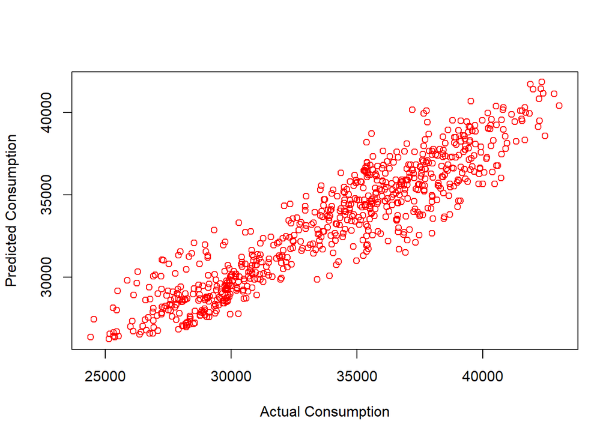

```r
plot(test_cons,predicted,xlab = "Actual Consumption", ylab = "Predicted Consumption",col = "red")
```

In linear regression, x2(lag168) has more importance than x1(lag48) as expected.Hence,using 7 days ago as a approach is reliable to predict next day’s consumption.Mape value for testing data is 4.12% and it is high compared to testing error that is found in Task A.The reason is that same coefficients is used for each hour but consumption rate at nights lower than other hours.In order to obtain more accurate results, we have to consider additional variables and information.

#### TASK C

In order to predict next day consumption,using the same coefficients may not be correct since the consumption behavior at nights can be different and seasonality is important parameter.Therefore, modeling each hour separately can be more accurate approach to the same problem.Linear regression model is implemented for each hour using the same training period (24 models) and mape values are calculated.

```r
h = c(1:24)
hours = rep(h, times = 1759)
hours_test = rep(h,times = 30)
training_data <- cbind(training_data,hours)
testing_data <- cbind(testing_data,hours_test)

# Create empty vectors to use in the for loop
predicted_hour <- c()
fit_lreg_hour <- c()
mape_hour <- c()
coeff <-matrix(0,24,3)
for (i in 1:24) {
  hour_data <- filter(training_data, hours == i)
  train_data_hour <- cbind(hour_data$lag_48, hour_data$lag_168)
  train_data_hour <- data.frame(train_data_hour)
  train_cons_hour <- hour_data$Consumption
  fit_lreg_hour <- lm(train_cons_hour~.,data = train_data_hour)
  coeff[i,] <- fit_lreg_hour$coefficients
  hour_data_testing <- filter(testing_data, hours_test == i)
  X1 = hour_data_testing$lag_48
  X2 = hour_data_testing$lag_168
  predicted_hour <- predict(fit_lreg_hour,hour_data_testing)

  test_cons <- hour_data_testing$Consumption
  mape_hour[i] <-  MAPE(y_pred = predicted_hour, y_true = test_cons)
  print(mape_hour[i])

}
```

```
## [1] 0.03266895
## [1] 0.03269987
## [1] 0.03385306
## [1] 0.0319038
## [1] 0.03168092
## [1] 0.03156634
## [1] 0.03131344
## [1] 0.03747448
## [1] 0.04590345
## [1] 0.0529984
## [1] 0.05841779
## [1] 0.05990204
## [1] 0.06233275
## [1] 0.0635518
## [1] 0.06189651
## [1] 0.05845919
## [1] 0.04968481
## [1] 0.04506409
## [1] 0.03676734
## [1] 0.03381575
## [1] 0.03117455
## [1] 0.0311126
## [1] 0.03126492
## [1] 0.03356428
```

```r
coeff <- as.data.frame(coeff)
names(coeff)<- c("Intercept","lag48","lag168")
print(coeff)
```

```
##    Intercept     lag48    lag168
## 1   2191.321 0.4868831 0.4428359
## 2   2120.452 0.4919552 0.4364232
## 3   2831.137 0.4753444 0.4252267
## 4   2229.137 0.4927967 0.4269401
## 5   2204.258 0.4746859 0.4449727
## 6   2225.031 0.4398487 0.4784599
## 7   2126.946 0.3759635 0.5462000
## 8   2310.651 0.2663126 0.6528305
## 9   3232.765 0.1737235 0.7255429
## 10  3594.994 0.1743794 0.7206583
## 11  3740.841 0.2062089 0.6868558
## 12  3958.706 0.2249924 0.6635927
## 13  3662.112 0.2802066 0.6131376
## 14  3806.670 0.3035491 0.5867997
## 15  4066.615 0.2597276 0.6255587
## 16  3950.800 0.2563915 0.6319420
## 17  3815.717 0.2471083 0.6456301
## 18  3389.937 0.2620916 0.6430749
## 19  3018.022 0.3337088 0.5819842
## 20  3163.115 0.3868581 0.5250949
## 21  2782.314 0.4080330 0.5143698
## 22  2658.049 0.4290922 0.4954232
## 23  2825.549 0.4427003 0.4753820
## 24  2541.261 0.4510817 0.4720343
```

It can be seen that mape values are varying for different hours.Also, lag 168 has more importance for 06.00 to 18.00 through the coefficients that means 7 days ago consumption values are significant between these hours.The hourly evaluation without any additional information may not be effective method to predict next day’s consumption but using consumption of one week ago is more reliable in this case.

#### TASK D

In this task, applying alternative approach that all hourly consumption values of last week (same day) can be important in the prediction of the next day’s consumption is considered.The data is converted long format to wide format.Since there is a strong correlation between these predictors,penalized regression approach is used for modeling.Lasso regression is applied for each hour using the same training period (24 models) and test performance is reported.

```r
# Convert data long format to wide format
# For training data
training_data_lag48 <- select(training_data, c(1,4,6))
wide_training48= spread(training_data_lag48, key = hours, value = lag_48)
training_data_lag168 <- select(training_data, c(1,5,6))
wide_training168 = spread(training_data_lag168, key = hours, value = lag_168)
wide_training = cbind(wide_training48,wide_training168[,2:25])
# For testing data
testing_data_lag48 <- select(testing_data, c(1,4,6))
wide_testing48= spread(testing_data_lag48, key = hours_test, value = lag_48)
testing_data_lag168 <- select(testing_data, c(1,5,6))
wide_testing168 = spread(testing_data_lag168, key = hours_test, value = lag_168)
wide_testing = cbind(wide_testing48,wide_testing168[,2:25])

# Add wide format of consumption to train data
wide_consumption = select(training_data, c(1,3,6))
wide_cons_training = spread(wide_consumption, key = hours, value = Consumption)
wide_training = cbind(wide_training,wide_cons_training[,2:25])



# Add wide format of consumption to train data
wide_consumption_test = select(testing_data, c(1,3,6))
wide_cons_testing = spread(wide_consumption_test, key = hours_test, value = Consumption)
wide_testing = cbind(wide_testing,wide_cons_testing[,2:25])

colnames(wide_testing)[50:73] <- c("cons_01", "cons_02" , "cons_03", "cons_04","cons_05","cons_06",
                                   "cons_07", "cons_08" , "cons_09", "cons_10","cons_11","cons_12",
                                   "cons_13", "cons_14" , "cons_15", "cons_16","cons_17","cons_18",
                                   "cons_19", "cons_20" , "cons_21", "cons_22","cons_23","cons_24")



wtrain_cons = wide_cons_training[,2:25]
wtrain_data = wide_training[,2:49]
wtest_data = wide_testing[,2:49]
wtrain_data = as.matrix(wtrain_data)
wtest_data = as.matrix(wtest_data)

# Mape for 00:00
wtrain_cons1 = as.matrix(wtrain_cons[,1])
cv1 = cv.glmnet(wtrain_data,wtrain_cons1,nfolds=10,family ='gaussian')$lambda.min
lasso1 = glmnet(wtrain_data, wtrain_cons1, family='gaussian',lambda = cv1)
predict1<-predict(lasso1,wtest_data)
wide_cons1 = wide_cons_testing[,2]
mape1 = MAPE(y_pred = predict1, y_true = wide_cons1)

# Mape for 01:00
wtrain_cons2 = as.matrix(wtrain_cons[,2])
cv2 = cv.glmnet(wtrain_data,wtrain_cons2,nfolds=10,family ='gaussian')$lambda.min
lasso2 = glmnet(wtrain_data, wtrain_cons2, family='gaussian',lambda = cv2)
predict2<-predict(lasso2,wtest_data)
wide_cons2 = wide_cons_testing[,3]
mape2 = MAPE(y_pred = predict2, y_true = wide_cons2)

# Mape for 02:00
wtrain_cons3 = as.matrix(wtrain_cons[,3])
cv3 = cv.glmnet(wtrain_data,wtrain_cons3,nfolds=10,family ='gaussian')$lambda.min
lasso3 = glmnet(wtrain_data, wtrain_cons3, family='gaussian',lambda = cv3)
predict3<-predict(lasso3,wtest_data)
wide_cons3 = wide_cons_testing[,4]
mape3 = MAPE(y_pred = predict3, y_true = wide_cons3)

# Mape for 03:00
wtrain_cons4 = as.matrix(wtrain_cons[,4])
cv4 = cv.glmnet(wtrain_data,wtrain_cons4,nfolds=10,family ='gaussian')$lambda.min
lasso4 = glmnet(wtrain_data, wtrain_cons4, family='gaussian',lambda = cv4)
predict4<-predict(lasso4,wtest_data)
wide_cons4 = wide_cons_testing[,5]
mape4 = MAPE(y_pred = predict4, y_true = wide_cons4)

# Mape for 04:00
wtrain_cons5 = as.matrix(wtrain_cons[,5])
cv5 = cv.glmnet(wtrain_data,wtrain_cons5,nfolds=10,family ='gaussian')$lambda.min
lasso5 = glmnet(wtrain_data, wtrain_cons5, family='gaussian',lambda = cv5)
predict5<-predict(lasso5,wtest_data)
wide_cons5 = wide_cons_testing[,6]
mape5 = MAPE(y_pred = predict5, y_true = wide_cons5)

# Mape for 05:00
wtrain_cons6 = as.matrix(wtrain_cons[,6])
cv6 = cv.glmnet(wtrain_data,wtrain_cons6,nfolds=10,family ='gaussian')$lambda.min
lasso6 = glmnet(wtrain_data, wtrain_cons6, family='gaussian',lambda = cv6)
predict6<-predict(lasso6,wtest_data)
wide_cons6 = wide_cons_testing[,7]
mape6 = MAPE(y_pred = predict6, y_true = wide_cons6)

# Mape for 06:00
wtrain_cons7 = as.matrix(wtrain_cons[,7])
cv7 = cv.glmnet(wtrain_data,wtrain_cons7,nfolds=10,family ='gaussian')$lambda.min
lasso7 = glmnet(wtrain_data, wtrain_cons7, family='gaussian',lambda = cv7)
predict7<-predict(lasso7,wtest_data)
wide_cons7 = wide_cons_testing[,8]
mape7 = MAPE(y_pred = predict7, y_true = wide_cons7)

# Mape for 07:00
wtrain_cons8 = as.matrix(wtrain_cons[,8])
cv8 = cv.glmnet(wtrain_data,wtrain_cons8,nfolds=10,family ='gaussian')$lambda.min
lasso8 = glmnet(wtrain_data, wtrain_cons8, family='gaussian',lambda = cv8)
predict8<-predict(lasso8,wtest_data)
wide_cons8 = wide_cons_testing[,9]
mape8 = MAPE(y_pred = predict8, y_true = wide_cons8)

# Mape for 08:00
wtrain_cons9 = as.matrix(wtrain_cons[,9])
cv9 = cv.glmnet(wtrain_data,wtrain_cons9,nfolds=10,family ='gaussian')$lambda.min
lasso9 = glmnet(wtrain_data, wtrain_cons9, family='gaussian',lambda = cv9)
predict9<-predict(lasso9,wtest_data)
wide_cons9 = wide_cons_testing[,10]
mape9 = MAPE(y_pred = predict9, y_true = wide_cons9)

# Mape for 09:00
wtrain_cons10 = as.matrix(wtrain_cons[,10])
cv10 = cv.glmnet(wtrain_data,wtrain_cons10,nfolds=10,family ='gaussian')$lambda.min
lasso10 = glmnet(wtrain_data, wtrain_cons10, family='gaussian',lambda = cv10)
predict10<-predict(lasso10,wtest_data)
wide_cons10 = wide_cons_testing[,11]
mape10 = MAPE(y_pred = predict10, y_true = wide_cons10)

# Mape for 10:00
wtrain_cons11 = as.matrix(wtrain_cons[,11])
cv11 = cv.glmnet(wtrain_data,wtrain_cons11,nfolds=10,family ='gaussian')$lambda.min
lasso11 = glmnet(wtrain_data, wtrain_cons11, family='gaussian',lambda = cv11)
predict11<-predict(lasso11,wtest_data)
wide_cons11 = wide_cons_testing[,12]
mape11 = MAPE(y_pred = predict11, y_true = wide_cons11)

# Mape for 11:00
wtrain_cons12 = as.matrix(wtrain_cons[,12])
cv12 = cv.glmnet(wtrain_data,wtrain_cons12,nfolds=10,family ='gaussian')$lambda.min
lasso12 = glmnet(wtrain_data, wtrain_cons12, family='gaussian',lambda = cv12)
predict12<-predict(lasso12,wtest_data)
wide_cons12 = wide_cons_testing[,13]
mape12 = MAPE(y_pred = predict12, y_true = wide_cons12)

# Mape for 12:00
wtrain_cons13 = as.matrix(wtrain_cons[,13])
cv13 = cv.glmnet(wtrain_data,wtrain_cons13,nfolds=10,family ='gaussian')$lambda.min
lasso13 = glmnet(wtrain_data, wtrain_cons13, family='gaussian',lambda = cv13)
predict13<-predict(lasso13,wtest_data)
wide_cons13 = wide_cons_testing[,14]
mape13 = MAPE(y_pred = predict13, y_true = wide_cons13)

# Mape for 13:00
wtrain_cons14 = as.matrix(wtrain_cons[,14])
cv14 = cv.glmnet(wtrain_data,wtrain_cons14,nfolds=10,family ='gaussian')$lambda.min
lasso14 = glmnet(wtrain_data, wtrain_cons14, family='gaussian',lambda = cv14)
predict14<-predict(lasso14,wtest_data)
wide_cons14 = wide_cons_testing[,15]
mape14 = MAPE(y_pred = predict14, y_true = wide_cons14)

# Mape for 14:00
wtrain_cons15 = as.matrix(wtrain_cons[,15])
cv15 = cv.glmnet(wtrain_data,wtrain_cons15,nfolds=10,family ='gaussian')$lambda.min
lasso15 = glmnet(wtrain_data, wtrain_cons15, family='gaussian',lambda = cv15)
predict15<-predict(lasso15,wtest_data)
wide_cons15 = wide_cons_testing[,16]
mape15 = MAPE(y_pred = predict15, y_true = wide_cons15)

# Mape for 15:00
wtrain_cons16 = as.matrix(wtrain_cons[,16])
cv16 = cv.glmnet(wtrain_data,wtrain_cons16,nfolds=10,family ='gaussian')$lambda.min
lasso16 = glmnet(wtrain_data, wtrain_cons16, family='gaussian',lambda = cv16)
predict16<-predict(lasso16,wtest_data)
wide_cons16 = wide_cons_testing[,17]
mape16 = MAPE(y_pred = predict16, y_true = wide_cons16)

# Mape for 16:00
wtrain_cons17 = as.matrix(wtrain_cons[,17])
cv17 = cv.glmnet(wtrain_data,wtrain_cons17,nfolds=10,family ='gaussian')$lambda.min
lasso17 = glmnet(wtrain_data, wtrain_cons17, family='gaussian',lambda = cv17)
predict17<-predict(lasso17,wtest_data)
wide_cons17 = wide_cons_testing[,18]
mape17 = MAPE(y_pred = predict17, y_true = wide_cons17)

# Mape for 17:00
wtrain_cons18 = as.matrix(wtrain_cons[,18])
cv18 = cv.glmnet(wtrain_data,wtrain_cons18,nfolds=10,family ='gaussian')$lambda.min
lasso18 = glmnet(wtrain_data, wtrain_cons18, family='gaussian',lambda = cv18)
predict18<-predict(lasso18,wtest_data)
wide_cons18 = wide_cons_testing[,19]
mape18 = MAPE(y_pred = predict18, y_true = wide_cons18)

# Mape for 18:00
wtrain_cons19 = as.matrix(wtrain_cons[,19])
cv19 = cv.glmnet(wtrain_data,wtrain_cons19,nfolds=10,family ='gaussian')$lambda.min
lasso19 = glmnet(wtrain_data, wtrain_cons19, family='gaussian',lambda = cv19)
predict19<-predict(lasso19,wtest_data)
wide_cons19 = wide_cons_testing[,20]
mape19 = MAPE(y_pred = predict19, y_true = wide_cons19)

# Mape for 19:00
wtrain_cons20 = as.matrix(wtrain_cons[,20])
cv20 = cv.glmnet(wtrain_data,wtrain_cons20,nfolds=10,family ='gaussian')$lambda.min
lasso20 = glmnet(wtrain_data, wtrain_cons20, family='gaussian',lambda = cv20)
predict20<-predict(lasso20,wtest_data)
wide_cons20 = wide_cons_testing[,21]
mape20 = MAPE(y_pred = predict20, y_true = wide_cons20)

# Mape for 20:00
wtrain_cons21 = as.matrix(wtrain_cons[,21])
cv21 = cv.glmnet(wtrain_data,wtrain_cons21 ,nfolds=10,family ='gaussian')$lambda.min
lasso21  = glmnet(wtrain_data, wtrain_cons21 , family='gaussian',lambda = cv21 )
predict21 <-predict(lasso21 ,wtest_data)
wide_cons21  = wide_cons_testing[,22]
mape21  = MAPE(y_pred = predict21 , y_true = wide_cons21 )

# Mape for 21:00
wtrain_cons22 = as.matrix(wtrain_cons[,22])
cv22 = cv.glmnet(wtrain_data,wtrain_cons22 ,nfolds=10,family ='gaussian')$lambda.min
lasso22  = glmnet(wtrain_data, wtrain_cons22 , family='gaussian',lambda = cv22 )
predict22 <-predict(lasso22 ,wtest_data)
wide_cons22  = wide_cons_testing[,23]
mape22  = MAPE(y_pred = predict22 , y_true = wide_cons22 )

# Mape for 22:00
wtrain_cons23 = as.matrix(wtrain_cons[,23])
cv23 = cv.glmnet(wtrain_data,wtrain_cons23 ,nfolds=10,family ='gaussian')$lambda.min
lasso23  = glmnet(wtrain_data, wtrain_cons23 , family='gaussian',lambda = cv23 )
predict23 <-predict(lasso23 ,wtest_data)
wide_cons23  = wide_cons_testing[,24]
mape23  = MAPE(y_pred = predict23 , y_true = wide_cons23 )

# Mape for 23:00
wtrain_cons24 = as.matrix(wtrain_cons[,24])
cv24 = cv.glmnet(wtrain_data,wtrain_cons24 ,nfolds=10,family ='gaussian')$lambda.min
lasso24  = glmnet(wtrain_data, wtrain_cons24 , family='gaussian',lambda = cv24 )
predict24 <-predict(lasso24 ,wtest_data)
wide_cons24  = wide_cons_testing[,25]
mape24  = MAPE(y_pred = predict24 , y_true = wide_cons24)

mape_lasso_hour = rbind(mape1,mape2,mape3,mape4,mape5,mape6,mape7,mape8,mape9,mape10,mape11,mape12,
                          mape13,mape14,mape15,mape16,mape17,mape18,mape19,mape20,mape21,mape22,mape23,mape24)
print(mape_lasso_hour)
```

```
##              [,1]
## mape1  0.01372062
## mape2  0.01574564
## mape3  0.01510731
## mape4  0.01408435
## mape5  0.01443655
## mape6  0.01399500
## mape7  0.01677844
## mape8  0.01886934
## mape9  0.02534059
## mape10 0.03540506
## mape11 0.04127553
## mape12 0.04319639
## mape13 0.04536411
## mape14 0.04411105
## mape15 0.04244178
## mape16 0.03765723
## mape17 0.02890523
## mape18 0.02109649
## mape19 0.01602256
## mape20 0.01587142
## mape21 0.01627006
## mape22 0.01736384
## mape23 0.01568910
## mape24 0.01830355
```

The errors that are obtained by using lasso regression are low compared to mape values from Task C for hourly consumption data.Also,mape values are decreased when the data become more complex and non-zero values are low. So, using lasso regression with more variable provides more reliable results in this case.

#### TASK F

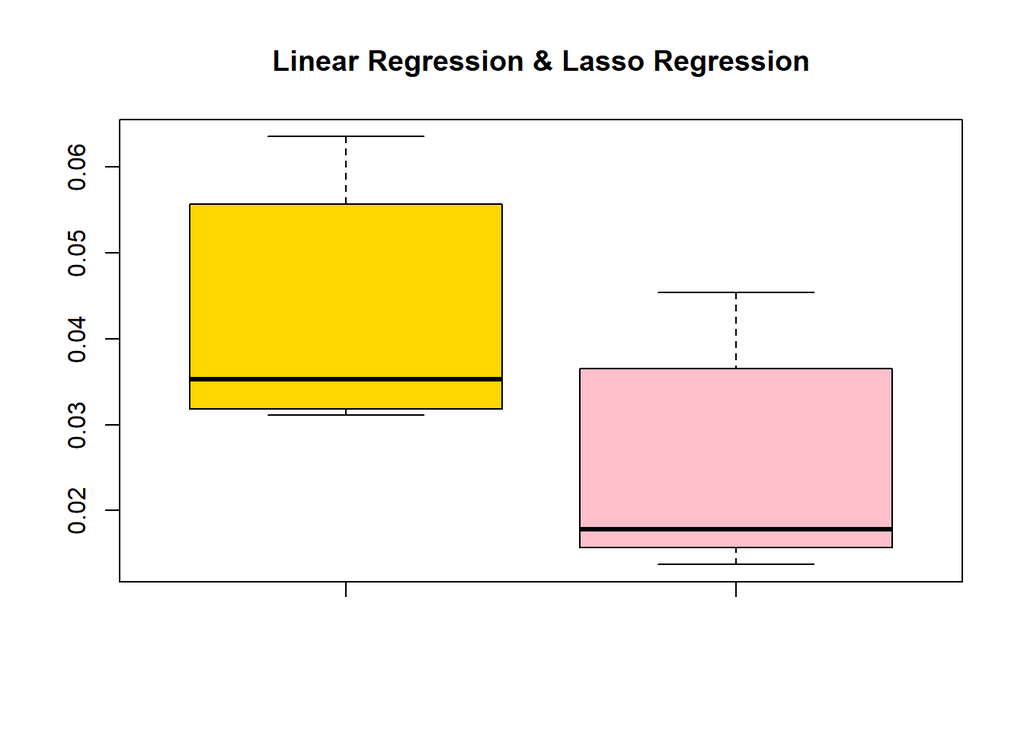

```r
# Draw multiple box plot
boxplot(mape_hour, mape_lasso_hour,
        main = "Linear Regression & Lasso Regression",
        col=c("gold","pink"))
```